# PSY 503: Lab 05 - Correlations, Regression with Dummy Coding

Steven Mesquiti

2024-10-08

# PSY 503: Lab 05 - Correlations, Regression with Dummy Coding

## Correlation and Regression

```r
if (!require("pacman")) install.packages("pacman") #run this if you don't have pacman
```

```r
library(pacman)
pacman::p_load(tidyverse, broom,corrr, patchwork, install = T)

# load in the data from the google drive
data_dir = "/Users/sm9518/Library/CloudStorage/GoogleDrive-sm9518@princeton.edu/My Drive/Classes/PSY-503/Lab-5/data"

parents = read.csv(file.path(data_dir, "galton_child_parent_heights.csv"))

palette = c("#772e25", "#c44536", "#ee9b00", "#197278", "#283d3b", "#9CC5A1", "#6195C6", "#ADA7C9", "#4D4861", "grey50")
palette_condition = c("#ee9b00", "#c44536","#005f73", "#283d3b", "#9CC5A1", "#6195C6", "#ADA7C9", "#4D4861")
plot_aes = theme_minimal() +
  theme(legend.position = "top",
        legend.text = element_text(size = 8),
        text = element_text(size = 12, family = "Futura Medium"),
        axis.text = element_text(color = "black"),
        axis.ticks.y = element_blank())
```

Let’s use the galton’s child parent height data as before. CSV file here: https://drive.google.com/file/d/1LK9jGBSpPr21S9_BzZhJi5Z68rB3JTEX/view?usp=sharing Your tasks are to: (1) Add two columns to the dataset: z_child_ht, and z_parent_ht which consists of standardized heights scores for the two variables

```r
parents = parents %>%
  mutate(z_child_ht = scale(child_ht),
         z_parent_ht = scale(parent_ht))

parents |>
  DT::datatable(rownames = FALSE, options = list(pageLength = 5))
```

| family_id | child_ht | parent_ht | z_child_ht | z_parent_ht |
| --- | --- | --- | --- | --- |
| F1 | 72.19999695 | 74.5 | [1.615210350846068] | [2.738660833467292] |
| F2 | 73.19999695 | 74.5 | [2.008523200890811] | [2.738660833467292] |
| F3 | 73.19999695 | 74.5 | [2.008523200890811] | [2.738660833467292] |
| F4 | 73.19999695 | 74.5 | [2.008523200890811] | [2.738660833467292] |
| F5 | 68.19999695 | 73.5 | [0.04195895066709589] | [2.215723126994525] |
| F6 | 69.19999695 | 73.5 | [0.4352718007118389] | [2.215723126994525] |
| F7 | 69.19999695 | 73.5 | [0.4352718007118389] | [2.215723126994525] |
| F8 | 70.19999695 | 73.5 | [0.8285846507565819] | [2.215723126994525] |
| F9 | 71.19999695 | 73.5 | [1.221897500801325] | [2.215723126994525] |
| F10 | 71.19999695 | 73.5 | [1.221897500801325] | [2.215723126994525] |

[output cut: 918 more lines]

2. Install the package “corrr” if you don’t have it already. Use corrr::correlate() to compute the correlation matrix/ pair-wise correlations for the variables in the data-frame. Display the matrix and save it within a new dataframe. Explain the observed results. You can also use cor() to get the correlation matrix, but corrr::correlate() works better with tidyverse.

```r
corrr::correlate(parents)
```

```
## Non-numeric variables removed from input: `family_id`
## Correlation computed with
## • Method: 'pearson'
## • Missing treated using: 'pairwise.complete.obs'
```

| term | child_ht | parent_ht | z_child_ht | z_parent_ht |
| --- | --- | --- | --- | --- |
| child_ht | NA | 0.4587332 | 1.0000000 | 0.4587332 |
| parent_ht | 0.4587332 | NA | 0.4587332 | 1.0000000 |
| z_child_ht | 1.0000000 | 0.4587332 | NA | 0.4587332 |
| z_parent_ht | 0.4587332 | 1.0000000 | 0.4587332 | NA |

> Results show that parent height and child height are positively correlated. The correlation coefficient is 0.459, which is a moderate correlation.
3. Create scatterplots of child_ht vs parent-ht, and z_child_ht vs z_parent_ht. Add a linear regression line to the plot (it is fine to use geom_smooth). Annotate the plot with the correlation value you had calculated earlier.

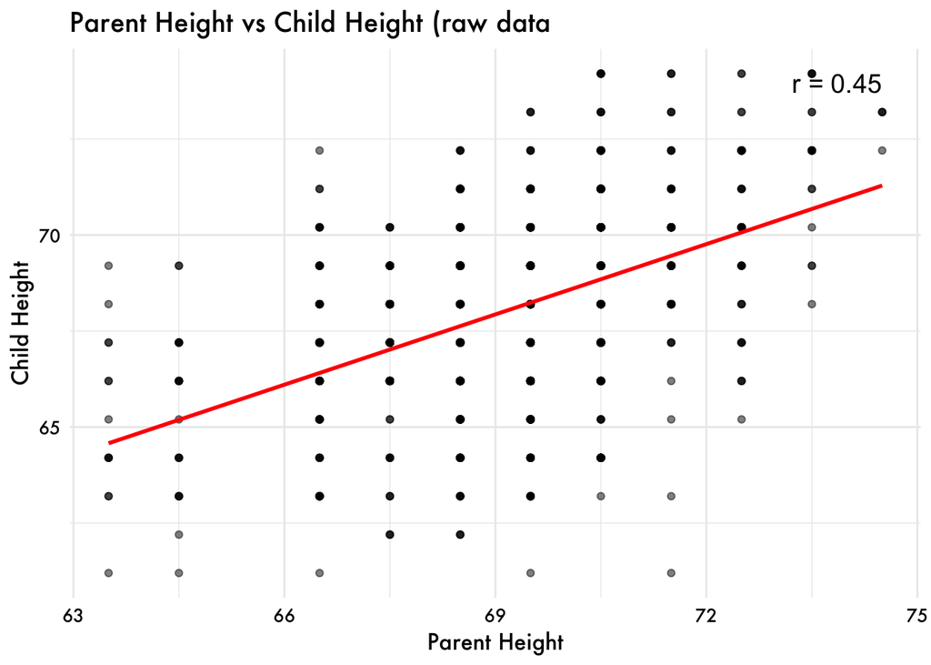

```r
parents |>
  ggplot(aes(x = parent_ht, y = child_ht)) +
  geom_point(alpha = 0.5) +
  geom_smooth(method = "lm", se = FALSE, color = "red") +
  labs(title = "Parent Height vs Child Height (raw data",
       x = "Parent Height",
       y = "Child Height") +
    annotate("text", x = max(parents$parent_ht), y = max(parents$child_ht),
           label = "r = 0.45", color = "black", hjust = 1, vjust = 1, size = 5) +
  plot_aes
```

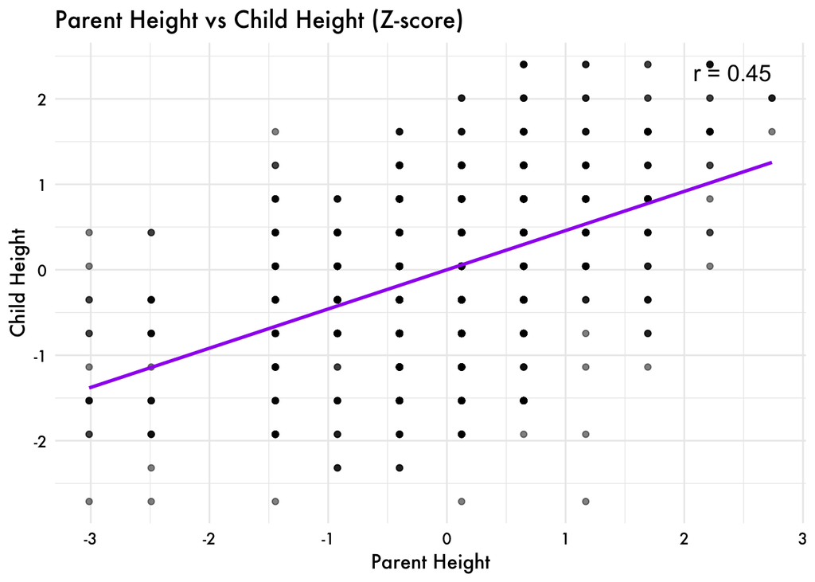

```r
parents |>
  ggplot(aes(x = z_parent_ht, y = z_child_ht)) +
  geom_point(alpha = 0.5) +
  geom_smooth(method = "lm", se = FALSE, color = "purple") +
  labs(title = "Parent Height vs Child Height (Z-score)",
       x = "Parent Height",
       y = "Child Height") +
    annotate("text", x = max(parents$z_parent_ht), y = max(parents$z_child_ht),
           label = "r = 0.45", color = "black", hjust = 1, vjust = 1, size = 5) +
  plot_aes
```

1. Fit a linear model to the data with
1. child_ht as the outcome variable, and parent_ht as the predictor/explanatory variable.

```r
model_1 = lm(child_ht ~ parent_ht, data = parents)


model_1 |> summary()
```

```
##
## Call:
## lm(formula = child_ht ~ parent_ht, data = parents)
##
## Residuals:
##     Min      1Q  Median      3Q     Max
## -8.2577 -1.4280  0.1323  1.5720  5.7918
##
## Coefficients:
##             Estimate Std. Error t value Pr(>|t|)
## (Intercept) 25.84856    2.69009   9.609   <2e-16 ***
## parent_ht    0.60992    0.03882  15.710   <2e-16 ***
## ---
## Signif. codes:  0 '***' 0.001 '**' 0.01 '*' 0.05 '.' 0.1 ' ' 1
##
## Residual standard error: 2.26 on 926 degrees of freedom
## Multiple R-squared:  0.2104, Adjusted R-squared:  0.2096
## F-statistic: 246.8 on 1 and 926 DF,  p-value: < 2.2e-16
```

2. z_child_ht the outcome variable, and z_parent_ht as the predictor/explanatory variable. Save these results as new r objects.

```r
model_2 = lm(z_child_ht ~ z_parent_ht, data = parents)

model_2 |>
  summary()
```

```
##
## Call:
## lm(formula = z_child_ht ~ z_parent_ht, data = parents)
##
## Residuals:
##     Min      1Q  Median      3Q     Max
## -3.2479 -0.5616  0.0520  0.6183  2.2780
##
## Coefficients:
##               Estimate Std. Error t value Pr(>|t|)
## (Intercept) -4.297e-13  2.918e-02    0.00        1
## z_parent_ht  4.587e-01  2.920e-02   15.71   <2e-16 ***
## ---
## Signif. codes:  0 '***' 0.001 '**' 0.01 '*' 0.05 '.' 0.1 ' ' 1
##
## Residual standard error: 0.8891 on 926 degrees of freedom
## Multiple R-squared:  0.2104, Adjusted R-squared:  0.2096
## F-statistic: 246.8 on 1 and 926 DF,  p-value: < 2.2e-16
```

2. Compare the co-efficients you observe for the two cases, and explain anything salient about what you see.

```r
glance(model_1)
```

| r.squared | adj.r.squared | sigma | statistic | p.value | df | logLik | AIC | BIC | deviance | df.residual | nobs |
| --- | --- | --- | --- | --- | --- | --- | --- | --- | --- | --- | --- |
| 0.2104361 | 0.2095835 | 2.260424 | 246.7994 | 1.760047e-49 | 1 | -2072.606 | 4151.213 | 4165.712 | 4731.412 | 926 | 928 |

```r
glance(model_2)
```

| r.squared | adj.r.squared | sigma | statistic | p.value | df | logLik | AIC | BIC | deviance | df.residual | nobs |
| --- | --- | --- | --- | --- | --- | --- | --- | --- | --- | --- | --- |
| 0.2104361 | 0.2095835 | 0.8890537 | 246.7994 | 1.760047e-49 | 1 | -1206.643 | 2419.287 | 2433.786 | 731.9257 | 926 | 928 |

> The R-squared value for model 1 is 0.21, while the R-squared value for model 2 is 0.21. The R-squared values are the same because the models are principally the same. However, the different fit statistics for each model differ.
4. We have come across the notion of total variance in the data, as well as variance that is explained or unexplained by a model. Calculate these three values for both set of models, and write about anything you find salient. As a hint, all of these can be found with the var command. The values you would be finding the variance of are either the (i) fitted data / predictions, (ii) observed data, or (iii) model residuals. You need to map these quantities to the different types of variance. Feel free to use augment() from broom, or referencing obtaining these variables from within the model object (lmfit_from_4a$fitted, lmfit_from_4a$resid)

Model 1 variance

```r
# 1. Get fitted values (predictions), residuals, and observed data
fitted_values <- model_1$fitted.values  # Extract predicted values
residuals <- model_1$residuals  # Extract residuals
observed_values <- parents$child_ht # Replace with the actual column name for observed data

# 2. Calculate Total Variance (Observed Data)
Model_1_total_variance <- var(observed_values)

# 3. Calculate Explained Variance (Fitted Data / Predictions)
Model_1_explained_variance <- var(fitted_values)

# 4. Calculate Unexplained Variance (Residuals)
Model_1_unexplained_variance <- var(residuals)

# 5. Print the results
cat("Total Variance for Model 1:", Model_1_total_variance,
    "\nExplained Variance for Model 1:", Model_1_explained_variance,
    "\nUnexplained Variance for Model 1:", Model_1_unexplained_variance, "\n")
```

```
## Total Variance for Model 1: 6.464333
## Explained Variance for Model 1: 1.360329
## Unexplained Variance for Model 1: 5.104004
```

Model 2 Variance

```r
# 1. Get fitted values (predictions), residuals, and observed data
fitted_values <- model_2$fitted.values  # Extract predicted values
residuals <- model_2$residuals  # Extract residuals
observed_values <- parents$z_child_ht # Replace with the actual column name for observed data

# 2. Calculate Total Variance (Observed Data)
Model_2_total_variance <- var(observed_values)

# 3. Calculate Explained Variance (Fitted Data / Predictions)
Model_2_explained_variance <- var(fitted_values)

# 4. Calculate Unexplained Variance (Residuals)
Model_2_unexplained_variance <- var(residuals)

# 5. Print the results
cat("Total Variance for Model 2:", Model_2_total_variance,
    "\nExplained Variance for Model 2:", Model_2_explained_variance,
    "\nUnexplained Variance for Model 2:", Model_2_unexplained_variance, "\n")
```

```
## Total Variance for Model 2: 1
## Explained Variance for Model 2: 0.2104361
## Unexplained Variance for Model 2: 0.7895639
```

5. Calculate explained variance/ total variance for both sets of models. Connect results here with results from 4c and 2.

```r
cat("Model 1 Explained Variance / Total Variance:", Model_1_explained_variance / Model_1_total_variance, "\n",
    "Model 2 Explained Variance / Total Variance:", Model_2_explained_variance / Model_2_total_variance, "\n",
    "See, they're equal :)")
```

```
## Model 1 Explained Variance / Total Variance: 0.2104361
##  Model 2 Explained Variance / Total Variance: 0.2104361
##  See, they're equal :)
```

## Part 2. Regression Intro (Continuous outcome, categorical predictors)

Let’s use the gapminder dataset that you have already worked with, and let’s use the most recent year of data. To motivate our analysis, fundamental question in economic development is “How does a country’s geographic location relate to its economic prosperity?” One interesting observation is that countries within the same continent often have similar levels of economic development. Do you guess differently about a country’s economy knowing that it is in Africa or that it is in Europe? Well, in addition to guessing, we can look at the data and attempt a regression analysis. gdpPercap could be a proxy for economic prosperity And we know the continents that each country belongs to.

```r
data <- gapminder::gapminder |>
  filter(year == max(year))

data |>
  filter(year == max(year)) |>
  DT::datatable(rownames = FALSE, options = list(pageLength = 20))
```

| country | continent | year | lifeExp | pop | gdpPercap |
| --- | --- | --- | --- | --- | --- |
| Afghanistan | Asia | 2007 | 43.828 | 31889923 | 974.5803384 |
| Albania | Europe | 2007 | 76.423 | 3600523 | 5937.029526 |
| Algeria | Africa | 2007 | 72.301 | 33333216 | 6223.367465 |
| Angola | Africa | 2007 | 42.731 | 12420476 | 4797.231267 |
| Argentina | Americas | 2007 | 75.32 | 40301927 | 12779.37964 |
| Australia | Oceania | 2007 | 81.235 | 20434176 | 34435.36744 |
| Austria | Europe | 2007 | 79.829 | 8199783 | 36126.4927 |
| Bahrain | Asia | 2007 | 75.635 | 708573 | 29796.04834 |
| Bangladesh | Asia | 2007 | 64.062 | 150448339 | 1391.253792 |
| Belgium | Europe | 2007 | 79.441 | 10392226 | 33692.60508 |

[output cut: 132 more lines]

With regression, we can ask questions like: 1. Is there a difference in GDP per capita across continents? 2. How much of the variation in countries’ GDP per capita can be explained by which continent they’re in? and so on.

Step 1: Visualize data

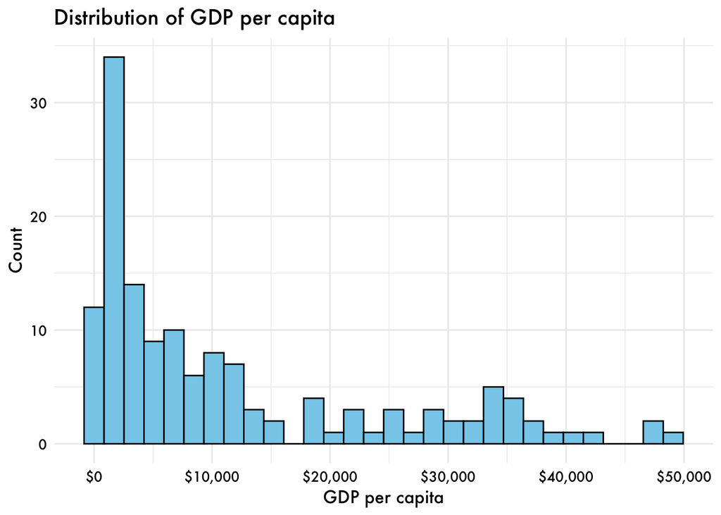

```r
data |>
ggplot(aes(x = gdpPercap)) +
geom_histogram(bins = 30, fill = "skyblue", color = "black") +
scale_x_continuous(labels = scales::dollar_format()) +
labs(title = "Distribution of GDP per capita",
x = "GDP per capita", y = "Count") +
  plot_aes
```

This data is right-skewed. It turns out that taking the log of per capita gdp in such scenarios helps with skewness. (It also helps economists talk more easily about rate of change of GDP and whether that is increasing or not) Let’s transform the variable and observe the results

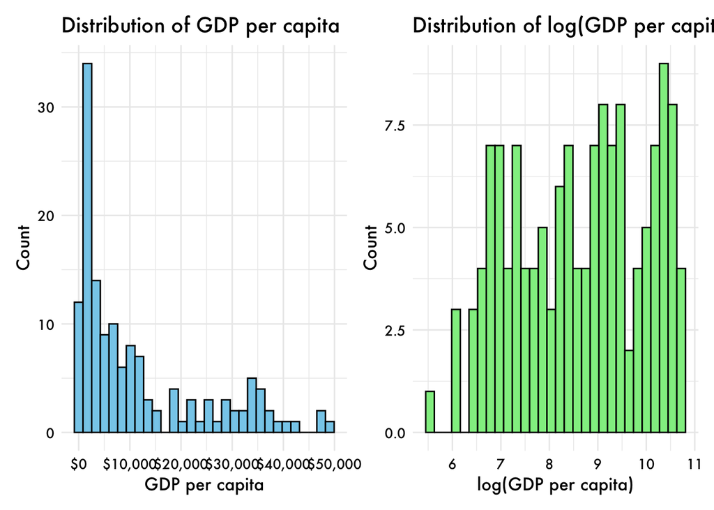

```r
# Let's use the most recent year of data
data = data |>
mutate(log_gdp = log(gdpPercap))




# Visualize the distribution of GDP per capita
p1 <- ggplot(data, aes(x = gdpPercap)) +
geom_histogram(bins = 30, fill = "skyblue", color = "black") +
scale_x_continuous(labels = scales::dollar_format()) +
labs(title = "Distribution of GDP per capita",
x = "GDP per capita", y = "Count") +
theme(axis.text.x = element_text(angle = 45, hjust = 1)) +  # Rotate x-axis labels
plot_aes




# Visualize the distribution of log(GDP per capita)
p2 <- ggplot(data, aes(x = log_gdp)) +
geom_histogram(bins = 30, fill = "lightgreen", color = "black") +
labs(title = "Distribution of log(GDP per capita)",
x = "log(GDP per capita)", y = "Count") +
  plot_aes

p1 + p2
```

The transformed values seem more like a normal distribution and with less skew. So let’s uses log_gdp as our outcome variable. Q5) Create dummy variables for the continent variable. Use the mutate() function to add new columns, one for each continent except one (which will serve as the reference category). Use Africa as the reference category. [Hint: (1) “as.integer(continent ==”Americas”)” returns the value of 1 when the continent is Americas, and 0 otherwise (2) Note again, that you’ll need one column less than all the possible continent columns] Show the first few rows of this new dataset.

```r
data_dummy = data |>
  mutate(continent_America = as.integer(continent == "Americas"),
         continent_Asia = as.integer(continent == "Asia"),
         continent_Europe = as.integer(continent == "Europe"),
         continent_Oceania = as.integer(continent == "Oceania"))

data_dummy |>
  DT::datatable()
```

|  | country | continent | year | lifeExp | pop | gdpPercap | log_gdp | continent_America | continent_Asia | continent_Europe | continent_Oceania |
| --- | --- | --- | --- | --- | --- | --- | --- | --- | --- | --- | --- |
| 1 | Afghanistan | Asia | 2007 | 43.828 | 31889923 | 974.5803384 | 6.882006956185797 | 0 | 1 | 0 | 0 |
| 2 | Albania | Europe | 2007 | 76.423 | 3600523 | 5937.029526 | 8.688964207477106 | 0 | 0 | 1 | 0 |
| 3 | Algeria | Africa | 2007 | 72.301 | 33333216 | 6223.367465 | 8.736066432319678 | 0 | 0 | 0 | 0 |
| 4 | Angola | Africa | 2007 | 42.731 | 12420476 | 4797.231267 | 8.475794211096686 | 0 | 0 | 0 | 0 |
| 5 | Argentina | Americas | 2007 | 75.32 | 40301927 | 12779.37964 | 9.455588185282302 | 1 | 0 | 0 | 0 |
| 6 | Australia | Oceania | 2007 | 81.235 | 20434176 | 34435.36744 | 10.44683943846056 | 0 | 0 | 0 | 1 |
| 7 | Austria | Europe | 2007 | 79.829 | 8199783 | 36126.4927 | 10.49478174497629 | 0 | 0 | 1 | 0 |
| 8 | Bahrain | Asia | 2007 | 75.635 | 708573 | 29796.04834 | 10.30213105766027 | 0 | 1 | 0 | 0 |
| 9 | Bangladesh | Asia | 2007 | 64.062 | 150448339 | 1391.253792 | 7.237960628192509 | 0 | 1 | 0 | 0 |
| 10 | Belgium | Europe | 2007 | 79.441 | 10392226 | 33692.60508 | 10.42503365843343 | 0 | 0 | 1 | 0 |

[output cut: 132 more lines]

Q6) Fit two models Model A is the empty model that predicts log_gdp by only includes an intercept. Model B is the model that predicts log_gdp based on continent.

```r
model_A = lm(log_gdp ~ 1, data = data_dummy)

model_A |>
  summary()
```

```
##
## Call:
## lm(formula = log_gdp ~ 1, data = data_dummy)
##
## Residuals:
##     Min      1Q  Median      3Q     Max
## -2.9898 -1.2230  0.1041  1.1828  2.1911
##
## Coefficients:
##             Estimate Std. Error t value Pr(>|t|)
## (Intercept)   8.6158     0.1138   75.72   <2e-16 ***
## ---
## Signif. codes:  0 '***' 0.001 '**' 0.01 '*' 0.05 '.' 0.1 ' ' 1
##
## Residual standard error: 1.356 on 141 degrees of freedom
```

```r
model_B = lm(log_gdp ~ continent, data = data_dummy)

model_B |>
  summary()
```

```
##
## Call:
## lm(formula = log_gdp ~ continent, data = data_dummy)
##
## Residuals:
##     Min      1Q  Median      3Q     Max
## -1.9300 -0.7032 -0.1170  0.5136  2.0236
##
## Coefficients:
##                   Estimate Std. Error t value Pr(>|t|)
## (Intercept)         7.4865     0.1332  56.208  < 2e-16 ***
## continentAmericas   1.5349     0.2338   6.566 9.85e-10 ***
## continentAsia       1.2542     0.2138   5.867 3.17e-08 ***
## continentEurope     2.4994     0.2202  11.351  < 2e-16 ***
## continentOceania    2.8039     0.6921   4.051 8.49e-05 ***
## ---
## Signif. codes:  0 '***' 0.001 '**' 0.01 '*' 0.05 '.' 0.1 ' ' 1
##
## Residual standard error: 0.9605 on 137 degrees of freedom
## Multiple R-squared:  0.5125, Adjusted R-squared:  0.4983
## F-statistic: 36.01 on 4 and 137 DF,  p-value: < 2.2e-16
```

Q7) Examine the results of the two models. What do you notice/ infer from it? Try using glance() for this model too, and elaborate on what you think is salient.

```r
glance(model_A)
```

| r.squared | adj.r.squared | sigma | statistic | p.value | df | logLik | AIC | BIC | deviance | df.residual | nobs |
| --- | --- | --- | --- | --- | --- | --- | --- | --- | --- | --- | --- |
| 0 | 0 | 1.355977 | NA | NA | NA | -244.2297 | 492.4594 | 498.371 | 259.2531 | 141 | 142 |

```r
glance(model_B)
```

| r.squared | adj.r.squared | sigma | statistic | p.value | df | logLik | AIC | BIC | deviance | df.residual | nobs |
| --- | --- | --- | --- | --- | --- | --- | --- | --- | --- | --- | --- |
| 0.5125171 | 0.4982841 | 0.9604646 | 36.00888 | 1.523395e-20 | 4 | -193.2162 | 398.4324 | 416.1673 | 126.3814 | 137 | 142 |

Q8) Create a strip plot of log_gdp for each continent, with a box plot overlaid. This will show both the individual country data points and the overall distribution for each continent. Use ggplot2 to create this visualization. Does this visual support the conclusions you drew from the R-squared value? [Hint: Strip plots are generated by using geom_jitter(); Given that you are overlaying the boxplot over the strip-plot, use the alpha parameter to ensure that the boxplot is not opaque and obscuring the datapoints. For the boxplot, set outlier.shape = NA, so that outliers are not plotted — we already have the data visualized including outliers]

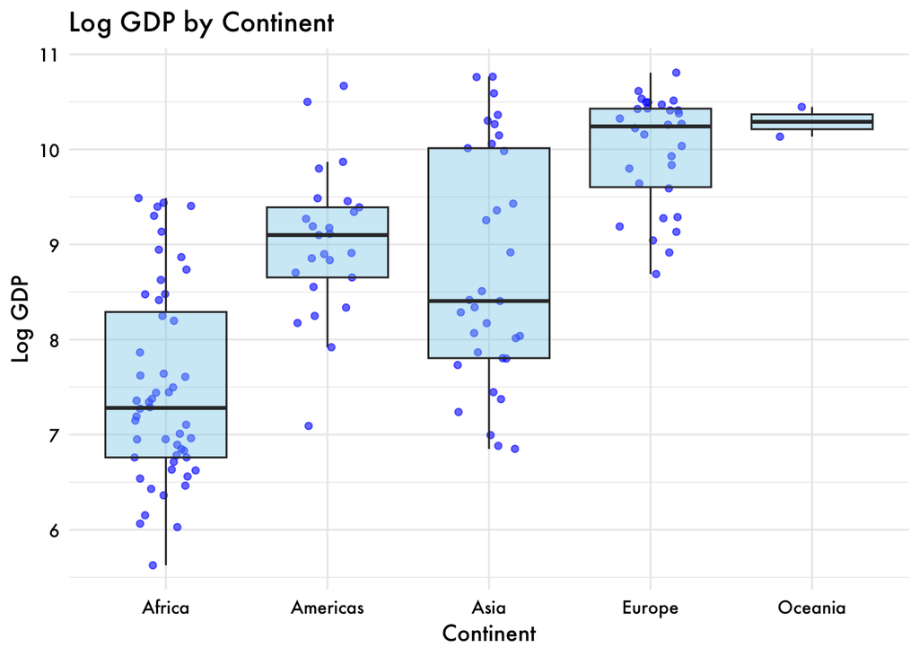

```r
ggplot(data, aes(x = continent, y = log_gdp)) +
  geom_jitter(alpha = 0.6, width = 0.2, color = "blue") +  # Strip plot with jitter
  geom_boxplot(outlier.shape = NA, alpha = 0.4, fill = "skyblue") +  # Boxplot without outliers
  labs(title = "Log GDP by Continent",
       x = "Continent",
       y = "Log GDP") +
  plot_aes
```